# Retail project

2. : ETS model selection : For estimating the ETS model, we firstly need to make sure three components : the trend, seasonal and the the error components, therefore we would use the STL decomposition plot to check those three components.

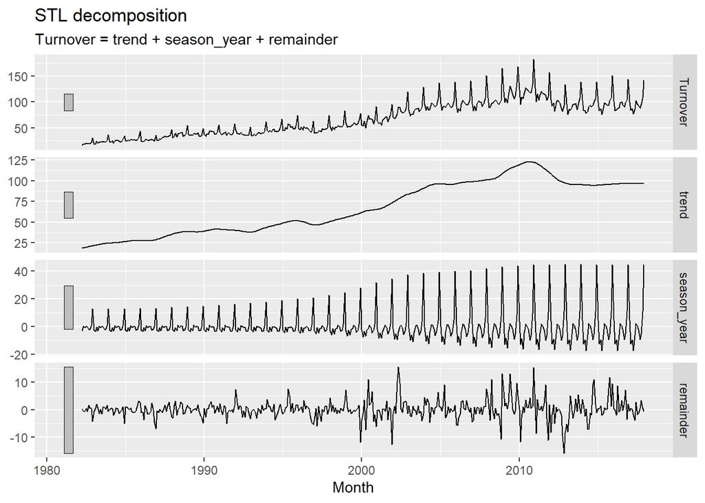

```r
myseries %>%
  model(STL(Turnover ~ trend(window = 21) + season(window = 13),robust = TRUE )) %>%
  components() %>%
  autoplot()
```

So, the potential ETS models are : `ETS(log(Turnover) ~ error('A') + trend('A') + season('A'))` `ETS(log(Turnover) ~ error('M') + trend('A') + season('A'))` `ETS(log(Turnover) ~ error('A') + trend('Ad') + season('A'))` `ETS(log(Turnover) ~ error('M') + trend('Ad') + season('A'))`

```r
myseries %>%
  model(
    AAA =  ETS(log(Turnover) ~ error('A') + trend('A') + season('A')),
    MAA =  ETS(log(Turnover) ~ error('M') + trend('A') + season('A')),
    AAdA = ETS(log(Turnover) ~ error('A') + trend('Ad') + season('A')),
    MAdA = ETS(log(Turnover) ~ error('M') + trend('Ad') + season('A'))
  ) %>%
  glance() %>%
  arrange(AICc) %>%
  select(.model,AICc)
```

```
## # A tibble: 4 x 2
##   .model  AICc
##   <chr>  <dbl>
## 1 AAdA    216.
## 2 AAA     219.
## 3 MAdA    255.
## 4 MAA     269.
```

Then, letting R automatically generate the model for us

```r
myseries %>%
  model(
    ETS(log(Turnover))
  ) %>%
  report()
```

```
## Series: Turnover
## Model: ETS(A,Ad,A)
## Transformation: log(.x)
##   Smoothing parameters:
##     alpha = 0.4812534
##     beta  = 0.00180846
##     gamma = 0.1302045
##     phi   = 0.979999
##
##   Initial states:
##         l          b          s1         s2          s3        s4         s5
##  2.825445 0.01877954 -0.01260358 -0.1179185 -0.07898695 0.3445507 0.03915428
##           s6          s7           s8         s9           s10        s11
##  -0.06408647 -0.06400786 -0.007530437 0.01157641 -0.0009936926 0.04033969
##          s12
##  -0.08949358
##
##   sigma^2:  0.0037
##
##      AIC     AICc      BIC
## 214.6727 216.3410 287.7789
```

The best model selected by R is ETS(A,Ad,A) which is identical to what we expected.Same as how we select the ARIMA model , we still use the RMSE based on the test set to select the model.

```r
fit <- myseries_tr %>%
  model(
    AAA =  ETS(log(Turnover) ~ error('A') + trend('A') + season('A')),
    MAA =  ETS(log(Turnover) ~ error('M') + trend('A') + season('A')),
    AAdA = ETS(log(Turnover) ~ error('A') + trend('Ad') + season('A')),
    MAdA = ETS(log(Turnover) ~ error('M') + trend('Ad') + season('A'))
  )

tidy(fit)
```

```
## # A tibble: 66 x 5
##    State           Industry                                .model term  estimate
##    <chr>           <chr>                                   <chr>  <chr>    <dbl>
##  1 South Australia Electrical and electronic goods retail~ AAA    alpha  4.62e-1
##  2 South Australia Electrical and electronic goods retail~ AAA    beta   1.00e-4
##  3 South Australia Electrical and electronic goods retail~ AAA    gamma  1.33e-1
##  4 South Australia Electrical and electronic goods retail~ AAA    l      2.91e+0
##  5 South Australia Electrical and electronic goods retail~ AAA    b      4.34e-3
##  6 South Australia Electrical and electronic goods retail~ AAA    s0    -1.09e-2
##  7 South Australia Electrical and electronic goods retail~ AAA    s1    -1.23e-1
##  8 South Australia Electrical and electronic goods retail~ AAA    s2    -6.18e-2
##  9 South Australia Electrical and electronic goods retail~ AAA    s3     3.56e-1
## 10 South Australia Electrical and electronic goods retail~ AAA    s4     4.52e-2
## # ... with 56 more rows
```

```r
glance(fit)
```

```
## # A tibble: 4 x 11
##   State  Industry .model  sigma2 log_ik   AIC  AICc   BIC     MSE    AMSE    MAE
##   <chr>  <chr>    <chr>    <dbl>  <dbl> <dbl> <dbl> <dbl>   <dbl>   <dbl>  <dbl>
## 1 South~ Electri~ AAA    3.80e-3  -79.2  192.  194.  260. 0.00365 0.00466 0.0471
## 2 South~ Electri~ MAA    2.60e-4  -99.9  234.  235.  302. 0.00375 0.00476 0.0122
## 3 South~ Electri~ AAdA   3.83e-3  -80.2  196.  198.  268. 0.00367 0.00464 0.0472
## 4 South~ Electri~ MAdA   2.56e-4  -95.3  227.  228.  299. 0.00367 0.00469 0.0119
```

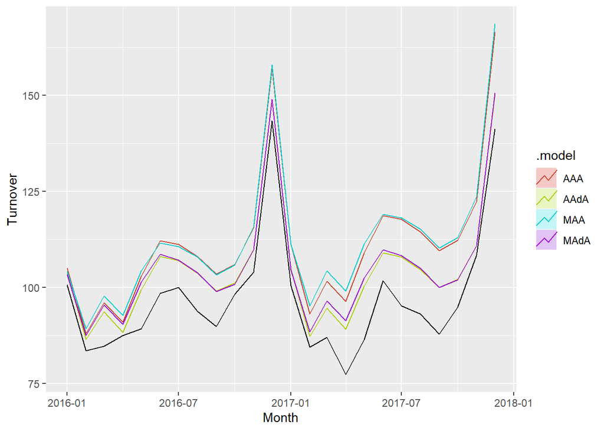

```r
fc <- fit %>%
  forecast(h = 24)

fc %>%
  autoplot(myseries_ts,level = NULL)
```

```r
accuracy(fc,myseries_ts) %>%
  select(.model,RMSE) %>%
  arrange(RMSE)
```

```
## # A tibble: 4 x 2
##   .model  RMSE
##   <chr>  <dbl>
## 1 AAdA    8.29
## 2 MAdA    9.00
## 3 AAA    15.3
## 4 MAA    16.2
```

Comparing RMSE,the test set accuracy argument also indictate that the the best model is ETS(log_Turnover ~ error(‘A’) + trend(‘Ad’) + season(‘A’)).

** Fit the data into test set

```r
# fit the ARIMA model on the training set
fit_ARIMA <- myseries_tr %>%
  model(ARIMA = ARIMA(log(Turnover) ~ pdq(1,1,2) + PDQ(0,1,1)))

# fit the ETS model on the training set
fit_ETS <- myseries_tr %>%
  model(ETS = ETS(log(Turnover) ~ error('A') + trend('Ad') + season('A')))
```

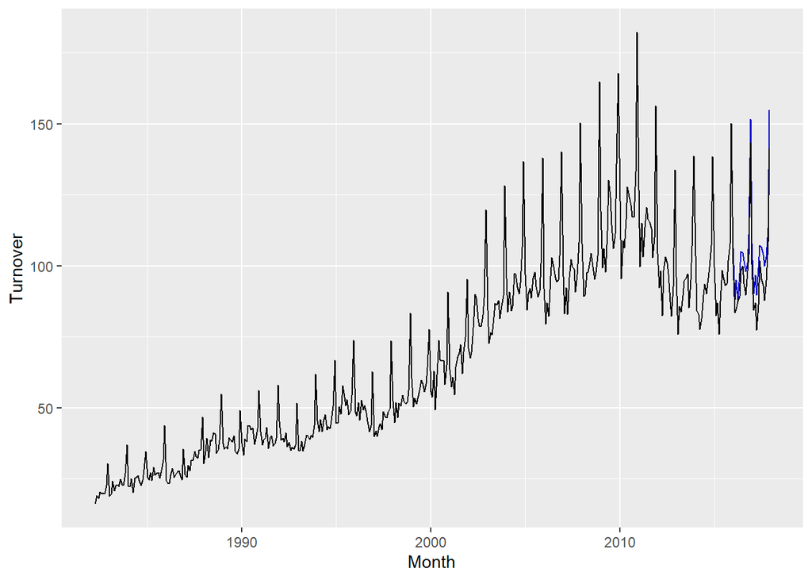

```r
# forecast using ARIMA model
fc_ARIMA <- fit_ARIMA %>%
  forecast(h = 24)
fc_ARIMA %>%
  autoplot(myseries,level = NULL)
```

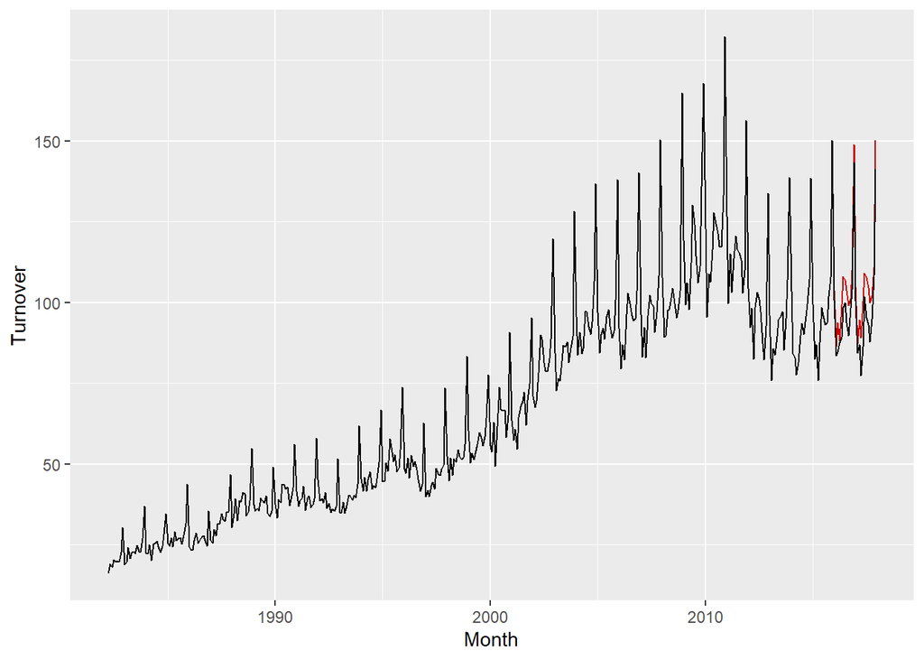

```r
# forecast using ETS model
fc_ETS <- fit_ETS %>%
  forecast(h = 24)
fc_ETS %>%
  autoplot(myseries,level = NULL,color = 'red')
```

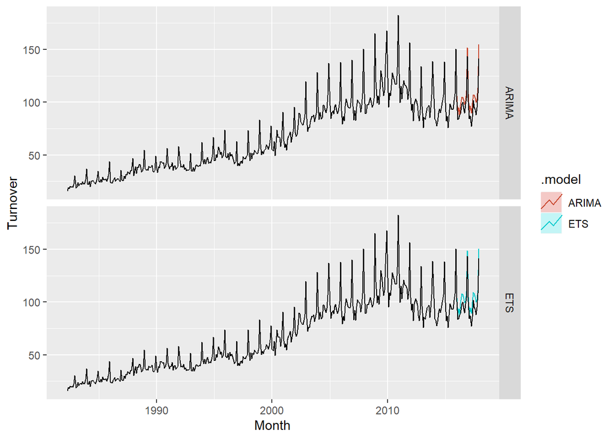

```r
# Combine ETS plot and ARIAM plot together

fit_combine <- myseries_tr %>%
  model(ETS = ETS(log(Turnover) ~ error('A') + trend('Ad') + season('A')),
       ARIMA = ARIMA(log(Turnover) ~ pdq(1,1,2) + PDQ(0,1,1)))

fc_combine <- fit_combine %>%
  forecast(h = "2 years")
fc_combine %>%
  autoplot(myseries,level = NULL) +
  facet_grid(vars(.model))
```

Compute the model accuracy using both training and test set

```r
model_accuracy <- bind_rows(
  accuracy(fit_ARIMA),
  accuracy(fit_ETS),
  accuracy(fc_ARIMA,myseries_ts),
  accuracy(fc_ETS,myseries_ts)
)

model_accuracy
```

```
## # A tibble: 4 x 11
##   State  Industry  .model .type     ME  RMSE   MAE    MPE  MAPE    MASE     ACF1
##   <chr>  <chr>     <chr>  <chr>  <dbl> <dbl> <dbl>  <dbl> <dbl>   <dbl>    <dbl>
## 1 South~ Electric~ ARIMA  Trai~ -0.179  3.99  2.81 -0.568  4.52   0.467  2.29e-2
## 2 South~ Electric~ ETS    Trai~  0.306  4.13  2.95  0.162  4.72   0.490  1.85e-1
## 3 South~ Electric~ ARIMA  Test  -7.90   8.56  7.90 -8.31   8.31 NaN     -2.76e-4
## 4 South~ Electric~ ETS    Test  -7.44   8.29  7.44 -7.92   7.92 NaN      2.31e-1
```

```r
model_accuracy %>%
  select(.model,.type,RMSE) %>%
  arrange(RMSE)
```

```
## # A tibble: 4 x 3
##   .model .type     RMSE
##   <chr>  <chr>    <dbl>
## 1 ARIMA  Training  3.99
## 2 ETS    Training  4.13
## 3 ETS    Test      8.29
## 4 ARIMA  Test      8.56
```

The table shows the accuracy for ARIMA model and ETS model under both training and test set. For the training set, the ARIMA model has a lower RMSE value 3.989224. For the test set, the ETS model has a slight lower RMSE value 8.294623. Since we need to put more weight into the accuracy for the test set.Finally, we concluded that ETS model does a better job for us.

# 4.Choose one ARIMA model and one ETS model based on this analysis and show parameter estimates, residual diagnostics, forecasts and prediction intervals for both models. Diagnostic checking for both models should include ACF graphs as well as the Ljung-Box test.

1. : parameter estimates :

```r
ARIMA <- myseries_tr %>%
  model(
    ARIMA = ARIMA(log(Turnover) ~ pdq(1,1,2) + PDQ(0,1,1))
  )
ARIMA %>% report() # 4 parameters
```

```
## Series: Turnover
## Model: ARIMA(1,1,2)(0,1,1)[12]
## Transformation: log(.x)
##
## Coefficients:
##           ar1     ma1      ma2     sma1
##       -0.6074  0.2060  -0.4135  -0.8363
## s.e.   0.2160  0.2038   0.0829   0.0298
##
## sigma^2 estimated as 0.003678:  log likelihood=537.07
## AIC=-1064.14   AICc=-1063.99   BIC=-1044.29
```

```r
ETS <- myseries_tr %>%
  model(
    ETS = ETS(log(Turnover) ~ error('A') + trend('Ad') + season('A'))
  )
ETS %>% report() # 17 parameters
```

```
## Series: Turnover
## Model: ETS(A,Ad,A)
## Transformation: log(.x)
##   Smoothing parameters:
##     alpha = 0.4240508
##     beta  = 0.004325963
##     gamma = 0.1406752
##     phi   = 0.979998
##
##   Initial states:
##         l         b          s1        s2          s3        s4         s5
##  2.882149 0.0175976 -0.00111931 -0.121033 -0.06431758 0.3567282 0.04476901
##           s6          s7           s8         s9        s10        s11
##  -0.06140799 -0.07496696 -0.005994969 0.01778787 0.01283281 0.01744646
##         s12
##  -0.1207245
##
##   sigma^2:  0.0038
##
##      AIC     AICc      BIC
## 196.3392 198.1112 268.4092
```

(2): 80% prediction interval

```r
# 80% prediction interval for the ARIMA model
PI1 <- fc_ARIMA %>%
  mutate(prediction_interval = hilo(.distribution,80))
PI1 %>%
  as_tsibble() %>%
  select(-State,-Industry,-.distribution)
```

```
## # A tsibble: 24 x 4 [1M]
## # Key:       .model [1]
##    .model    Month Turnover     prediction_interval
##    <chr>     <mth>    <dbl>                  <hilo>
##  1 ARIMA  2016 Jan    106.  [98.18612, 114.69801]80
##  2 ARIMA  2016 Feb     88.1 [80.29186,  96.23826]80
##  3 ARIMA  2016 Mar     95.0 [86.01725, 104.33281]80
##  4 ARIMA  2016 Apr     87.9 [78.91042,  97.35042]80
##  5 ARIMA  2016 May     97.5 [86.91688, 108.55637]80
##  6 ARIMA  2016 Jun    105.  [93.02055, 117.76768]80
##  7 ARIMA  2016 Jul    105.  [91.94474, 117.77812]80
##  8 ARIMA  2016 Aug    102.  [89.02316, 115.39315]80
##  9 ARIMA  2016 Sep     97.9 [85.08007, 111.49527]80
## 10 ARIMA  2016 Oct    101.  [87.28333, 115.61703]80
## # ... with 14 more rows
```

```r
# 80% prediction interval for the ETS model
PI2 <- fc_ETS %>%
  mutate(prediction_interval = hilo(.distribution,80))
PI2 %>%
  as_tsibble() %>%
  select(-State,-Industry,-.distribution)
```

```
## # A tsibble: 24 x 4 [1M]
## # Key:       .model [1]
##    .model    Month Turnover     prediction_interval
##    <chr>     <mth>    <dbl>                  <hilo>
##  1 ETS    2016 Jan    104.  [95.74104, 112.19660]80
##  2 ETS    2016 Feb     86.4 [79.08791,  93.98171]80
##  3 ETS    2016 Mar     93.7 [85.16700, 102.54349]80
##  4 ETS    2016 Apr     88.3 [79.74809,  97.22559]80
##  5 ETS    2016 May     99.4 [89.17270, 110.02329]80
##  6 ETS    2016 Jun    108.  [96.32731, 120.22642]80
##  7 ETS    2016 Jul    107.  [94.80116, 119.64519]80
##  8 ETS    2016 Aug    104.  [91.41334, 116.62121]80
##  9 ETS    2016 Sep     99.1 [86.82335, 111.93443]80
## 10 ETS    2016 Oct    101.  [88.17744, 114.85001]80
## # ... with 14 more rows
```

(3): residual diagnostics

(a):ARIMA model

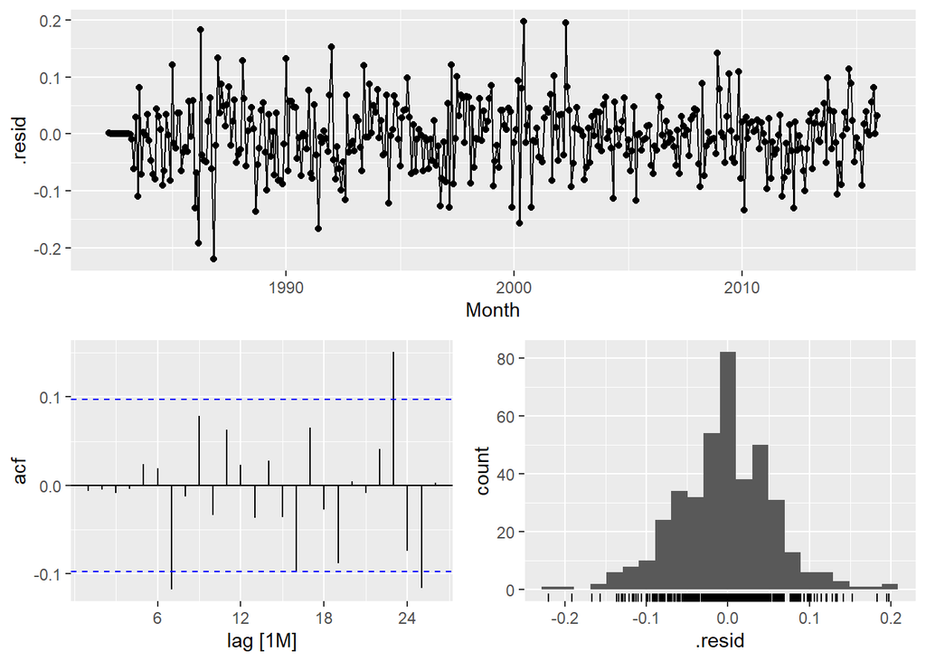

```r
# Residuals of the ARIMA model
fit_ARIMA %>% gg_tsresiduals() # significant spike at lag 7
```

```r
# Ljung_box test
augment(fit_ARIMA) %>%
  features(.resid,ljung_box,dof = 4,lag = 24) # dof = 4 because we have four parameters to estimate, lags = 24 since it's a monthly data. P-value = 0.01970 < 0.05 indicates that we can reject the null hypothesis under 5% significance level, so we could not assume that residual is white noise process.
```

```
## # A tibble: 1 x 5
##   State           Industry                              .model lb_stat lb_pvalue
##   <chr>           <chr>                                 <chr>    <dbl>     <dbl>
## 1 South Australia Electrical and electronic goods reta~ ARIMA     35.1    0.0197
```

2. : ETS model

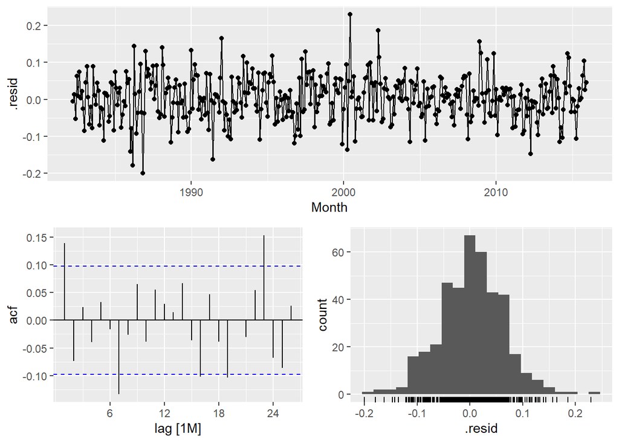

```r
# Residuals of the ETS model
fit_ETS %>% gg_tsresiduals() # significant spikes at lag 1 & 7
```

```r
# Ljung_box test
augment(fit_ETS) %>%
  features(.resid,ljung_box,dof = 17,lag = 24) # From the above analysis, we acknowledged that there are 17 parameters to be estimated. P-value = 1.366567e-08 < 0.05 indicates that we can reject the null hypothesis under 5% significance level, so we could not assume that residual is white noise process.
```

```
## # A tibble: 1 x 5
##   State          Industry                             .model lb_stat   lb_pvalue
##   <chr>          <chr>                                <chr>    <dbl>       <dbl>
## 1 South Austral~ Electrical and electronic goods ret~ ETS       50.1     1.37e-8
```

Both ARIMA model and ETS model can reject the null hypothesis which suggest that the residuals of both model did not follow the white noise process. Also by lokking at the ACFs from two models, we could see that both ACF contians significant lags suggesting the residuals are not independent(correlated),so the prediction interval may not be reliable, since the way hwo R generate the prediction interval is based on the assumption that the error terms are white noise process.

4. : Forecasting

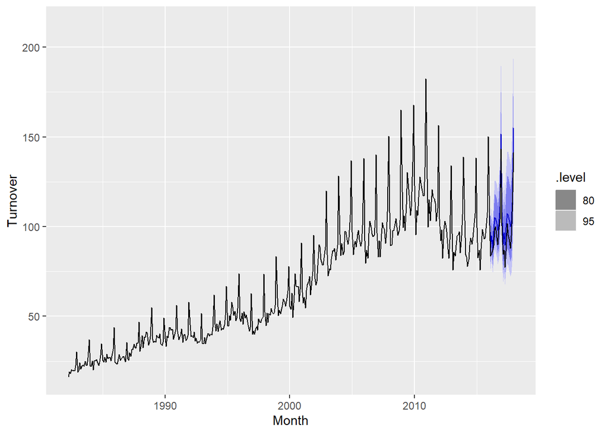

```r
# forecast using ARIMA model
fc_ARIMA <- fit_ARIMA %>%
  forecast(h = 24)
fc_ARIMA %>%
  autoplot(myseries)
```

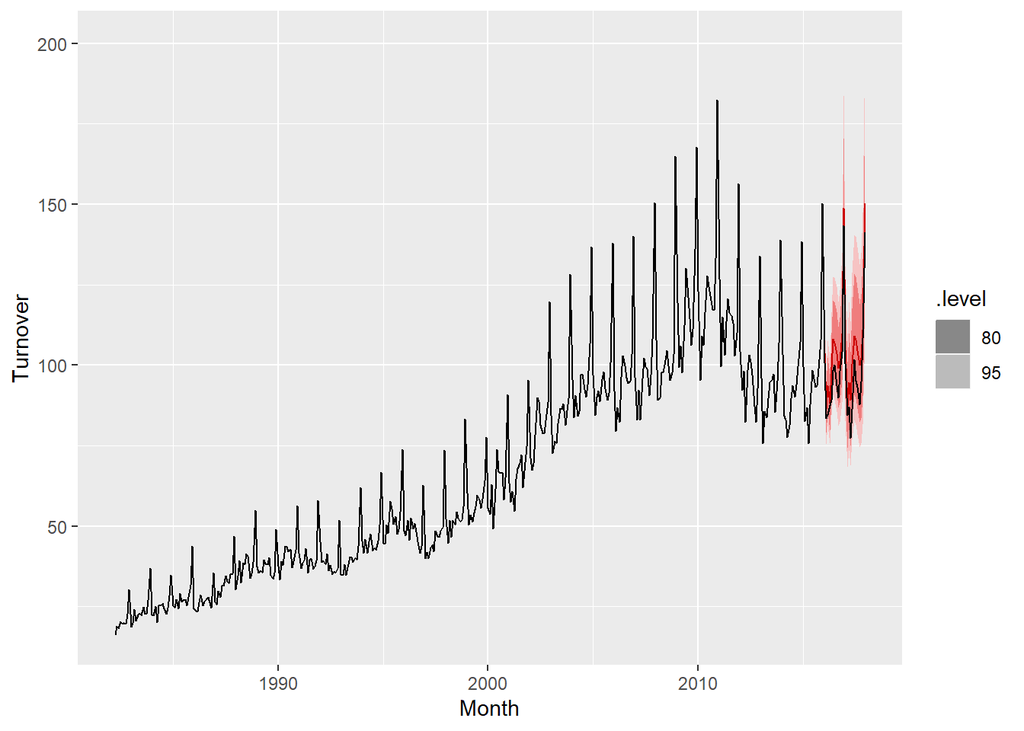

```r
# forecast using ETS model
fc_ETS <- fit_ETS %>%
  forecast(h = 24)
fc_ETS %>%
  autoplot(myseries,color = 'red')
```

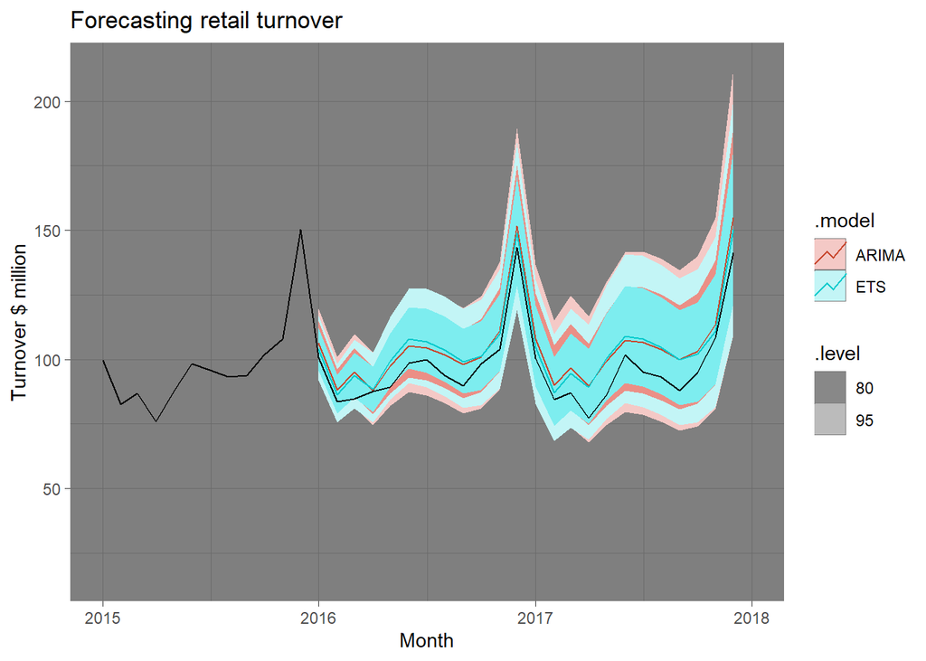

```r
# Combine them together
fit_overall <- myseries_tr %>%
  model(
    ARIMA = ARIMA(log(Turnover) ~ pdq(1,1,2) + PDQ(0,1,1)),
    ETS = ETS(log(Turnover) ~ error('A') + trend('Ad') + season('A'))
  )
fc_overall <- fit_overall %>%
  forecast(h = 24)

fc_overall %>%
  autoplot(myseries) +
  xlim(yearmonth(c('2015','2018'))) + theme_dark() +
  xlab("Month") +
  ylab("Turnover $ million") +
  ggtitle("Forecasting retail turnover")
```

The plot shows the actual value with point forecast with prediction interval, it can be observed that the prediction interval has covered all the point forecast, indicating we did a great job, also the ETS model did a better job since the point forecast from the ETS model are more close to the actual value.

# 5.Comparison of the results from each of your preferred models. Which method do you think gives the better forecasts? Explain with reference to the test-set.

```r
accuracy <- bind_rows(
  accuracy(fc_ARIMA,myseries_ts),
  accuracy(fc_ETS,myseries_ts)
)

accuracy
```

```
## # A tibble: 2 x 11
##   .model State   Industry     .type    ME  RMSE   MAE   MPE  MAPE  MASE     ACF1
##   <chr>  <chr>   <chr>        <chr> <dbl> <dbl> <dbl> <dbl> <dbl> <dbl>    <dbl>
## 1 ARIMA  South ~ Electrical ~ Test  -7.90  8.56  7.90 -8.31  8.31   NaN -2.76e-4
## 2 ETS    South ~ Electrical ~ Test  -7.44  8.29  7.44 -7.92  7.92   NaN  2.31e-1
```

```r
accuracy %>%
  select(.model,.type,RMSE) %>%
  arrange(RMSE)
```

```
## # A tibble: 2 x 3
##   .model .type  RMSE
##   <chr>  <chr> <dbl>
## 1 ETS    Test   8.29
## 2 ARIMA  Test   8.56
```

After comparing the RMSE values using the test set as the buliding blocks, we would suggest that the ETS(A,Ad,A) has a better performance since it has a smaller value for the RMSE component. Lower value of the RMSE indicate higer accuracy in forcasting, in that sense, ETS(A,Ad,A) is a better model.

# 6.Apply your two chosen models to the full data set and produce out-of-sample point forecasts and 80% prediction intervals for each model for two years past the end of the data provided.

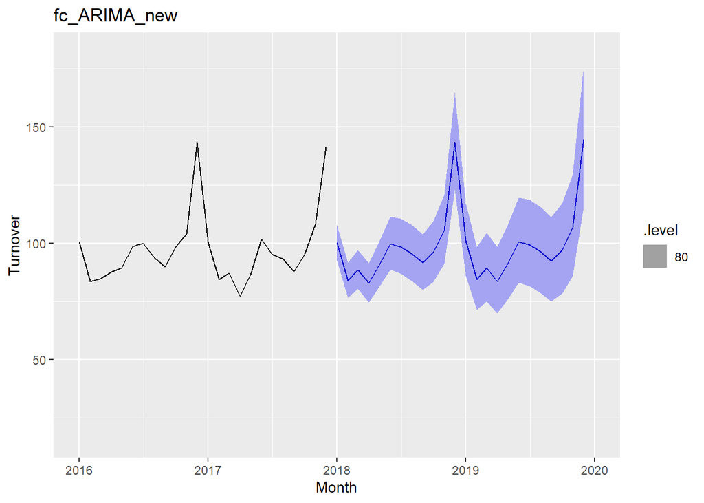

```r
fit_ARIMA_new <- myseries %>%
    model(
    ARIMA = ARIMA(log(Turnover) ~ pdq(1,1,2) + PDQ(0,1,1))
  )
fc_ARIMA_new <- fit_ARIMA_new %>%
  forecast(h = "2 years")

fc_ARIMA_new %>%
  autoplot(myseries,level = 80) +
  xlim(yearmonth(c('2016','2020'))) + ggtitle("fc_ARIMA_new")
```

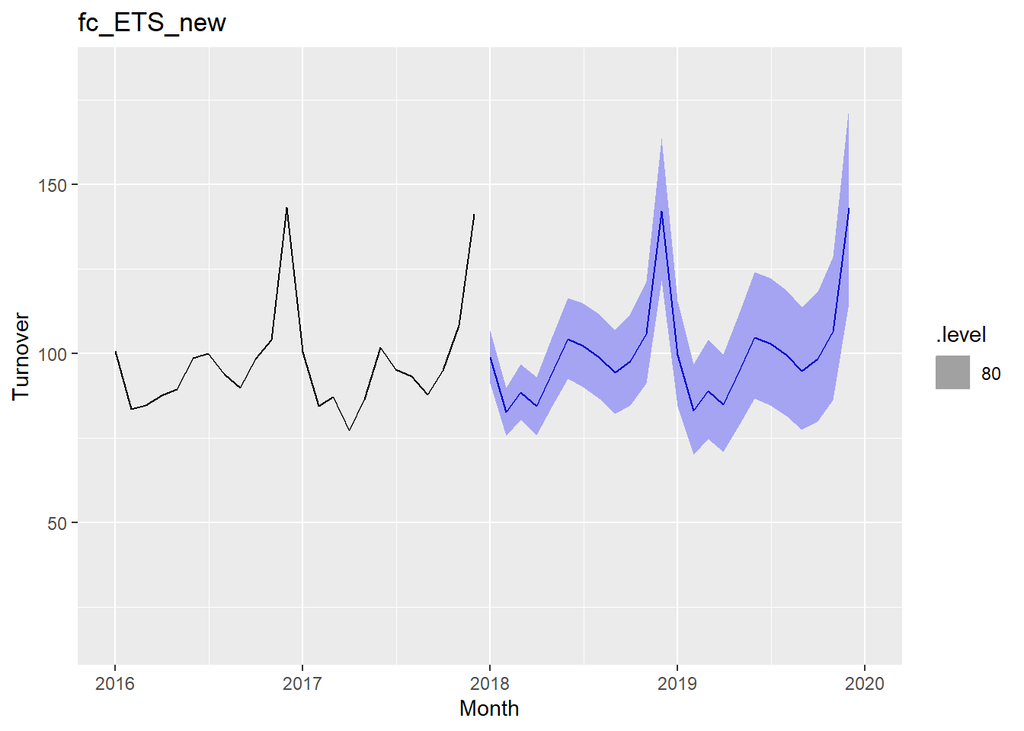

```r
PI3 <- fc_ARIMA_new %>%
  mutate(prediction_interval = hilo(.distribution,80))

fit_ETS_new <- myseries %>%
  model(
     ETS = ETS(log(Turnover) ~ error('A') + trend('Ad') + season('A'))
  )
fc_ETS_new <- fit_ETS_new %>%
  forecast( h = "2 years")

fc_ETS_new %>%
  autoplot(myseries,level = 80) +
  xlim(yearmonth(c('2016','2020')))  + ggtitle("fc_ETS_new")
```

```r
PI4 <- fc_ETS_new %>%
  mutate(prediction_interval = hilo(.distribution,80))
```

Applying a out-of-sample and 80% prediction interval, we could see that the proint forcasting did a good job for us, as it reasonably capture the trend and the seasonality in the original data, the prediction interval looks acceptable, as it is not too high or too low, but a little bittle wild. However, if we include 95% prediction interval, it will cause the prediction interval more wilder.

# 7.Obtain up-to-date data from the ABS website (Cat. 8501.0, Table 11), and compare your forecasts with the actual numbers. How well did you do? [Hint: the readabs package can help in getting the data into R.]

```r
abs <- read_abs(series_id = "A3349361W")
```

```
## Finding filenames for tables corresponding to ABS series ID
```

```
## Attempting to download files from series ID , Retail Trade, Australia
```

```
## Extracting data from downloaded spreadsheets
```

```
## Tidying data from imported ABS spreadsheets
```

```r
abs
```

```
## # A tibble: 457 x 12
##    table_no sheet_no table_title date       series value series_type data_type
##    <chr>    <chr>    <chr>       <date>     <chr>  <dbl> <chr>       <chr>
##  1 8501011  Data1    TABLE 11. ~ 1982-04-01 Turno~  16   Original    FLOW
##  2 8501011  Data1    TABLE 11. ~ 1982-05-01 Turno~  19   Original    FLOW
##  3 8501011  Data1    TABLE 11. ~ 1982-06-01 Turno~  18.1 Original    FLOW
##  4 8501011  Data1    TABLE 11. ~ 1982-07-01 Turno~  20.3 Original    FLOW
##  5 8501011  Data1    TABLE 11. ~ 1982-08-01 Turno~  19.6 Original    FLOW
##  6 8501011  Data1    TABLE 11. ~ 1982-09-01 Turno~  19.9 Original    FLOW
##  7 8501011  Data1    TABLE 11. ~ 1982-10-01 Turno~  19.7 Original    FLOW
##  8 8501011  Data1    TABLE 11. ~ 1982-11-01 Turno~  22.7 Original    FLOW
##  9 8501011  Data1    TABLE 11. ~ 1982-12-01 Turno~  30.3 Original    FLOW
## 10 8501011  Data1    TABLE 11. ~ 1983-01-01 Turno~  18.8 Original    FLOW
## # ... with 447 more rows, and 4 more variables: collection_month <chr>,
## #   frequency <chr>, series_id <chr>, unit <chr>
```

```r
myseries_2020 <- abs %>%
  separate(col = series,into = c('Turnover','State','Industry'),sep = ";") %>%
  select(-Turnover) %>%
  rename(Turnover = 'value',Month = 'date') %>%
  select(State,Industry,series_id,Month,Turnover) %>%
  mutate(Month = yearmonth(Month)) %>%
  as_tsibble(index = Month) %>%
  filter(year(Month) < 2020)
myseries_2020
```

```
## # A tsibble: 453 x 5 [1M]
##    State           Industry                          series_id    Month Turnover
##    <chr>           <chr>                             <chr>        <mth>    <dbl>
##  1 "  South Austr~ "  Electrical and electronic goo~ A3349361W 1982 Apr     16
##  2 "  South Austr~ "  Electrical and electronic goo~ A3349361W 1982 May     19
##  3 "  South Austr~ "  Electrical and electronic goo~ A3349361W 1982 Jun     18.1
##  4 "  South Austr~ "  Electrical and electronic goo~ A3349361W 1982 Jul     20.3
##  5 "  South Austr~ "  Electrical and electronic goo~ A3349361W 1982 Aug     19.6
##  6 "  South Austr~ "  Electrical and electronic goo~ A3349361W 1982 Sep     19.9
##  7 "  South Austr~ "  Electrical and electronic goo~ A3349361W 1982 Oct     19.7
##  8 "  South Austr~ "  Electrical and electronic goo~ A3349361W 1982 Nov     22.7
##  9 "  South Austr~ "  Electrical and electronic goo~ A3349361W 1982 Dec     30.3
## 10 "  South Austr~ "  Electrical and electronic goo~ A3349361W 1983 Jan     18.8
## # ... with 443 more rows
```

After some data cleaning process, we get the newest tidy verison of the up-to-data data, since our two years forecast only forecast the value of turnover until 2019 Dec, for the accuarcy purpose, I shrink the dataset aimed to keep the volumn of the new dataet to make sure it also contain the value of turnover until 2019 Dec.

Compare the forecast with the actual numbers and check for its performance

```r
accuracy_new <- bind_rows(
  accuracy(fit_ARIMA_new),
  accuracy(fit_ETS_new),
  accuracy(fc_ARIMA_new,myseries_2020),
  accuracy(fc_ETS_new,myseries_2020)
) %>%
  group_by(.type)
accuracy_new$State[is.na(accuracy_new$State)] <- "South Australia"
accuracy_new$Industry[is.na(accuracy_new$Industry)] <- "Electrical and electronic goods retailing"

accuracy_new
```

```
## # A tibble: 4 x 11
## # Groups:   .type [2]
##   State   Industry    .model .type     ME  RMSE   MAE    MPE  MAPE  MASE    ACF1
##   <chr>   <chr>       <chr>  <chr>  <dbl> <dbl> <dbl>  <dbl> <dbl> <dbl>   <dbl>
## 1 South ~ Electrical~ ARIMA  Trai~ -0.194  3.98  2.84 -0.571  4.46 0.484 0.00962
## 2 South ~ Electrical~ ETS    Trai~  0.311  4.12  2.95  0.161  4.61 0.504 0.132
## 3 South ~ Electrical~ ARIMA  Test   5.06   7.04  5.57  4.67   5.24 0.952 0.679
## 4 South ~ Electrical~ ETS    Test   3.79   6.65  5.71  3.36   5.44 0.975 0.720
```

Comparing with the acctual data, both models give a reasonable forecast, but using the RMSE method, we could see that ETS model did a better job than ARIMA model since it has a lower RMSE value.

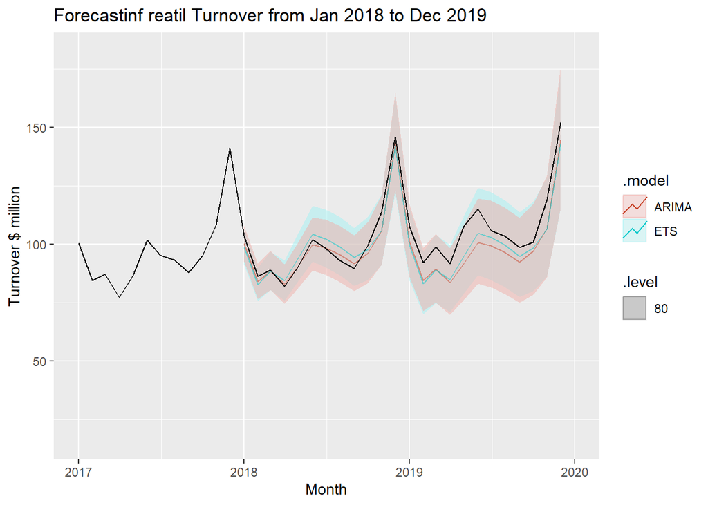

```r
fit_overall_new <- myseries %>%
  model(
     ARIMA = ARIMA(log(Turnover) ~ pdq(1,1,2) + PDQ(0,1,1)),
     ETS = ETS(log(Turnover) ~ error('A') + trend('Ad') + season('A'))
  )
fc_overall_new <- fit_overall_new %>%
  forecast(h = "2 years") %>%
  select(.model,Month,Turnover,.distribution)

fc_overall_new %>%
  autoplot(myseries_2020,level = 80,alpha = 0.5)+
  xlim(yearmonth(c("2017","2020"))) +
  xlab("Month") +
  ylab("Turnover $ million") +
  ggtitle("Forecastinf reatil Turnover from Jan 2018 to Dec 2019")
```

From the plot, we could observed that all the actual values fall inside the prediction interval,but the lower bond for the prediction interval seems too wild for the actual value, whcih means the model still could be imporved but required more precise and advanced setting.

# 8.A discussion of benefits and limitations of the models for your data

ARIMA model could only handle with additive error,if instead our data has multiplicative error, we need to do some additional work beforhands, otherwise, our model would be useless.But the ETS model could handle both additive error and multiplicative.For the benefits of ARIMA model, it accpet missing values, where an ETS cannot, and there are infinite possible models for the time series follows the ARIMA process, but there are only eight possible ETS models.

In general, ETS model perform better in the short term forecasting, which is the reason why we perfer ETS model in this project, also, all the ETS models are non-stationary so we do not need to difference the data to make it stationary whcih saves quiet a lot times for us, but if we want to investigate more precisly about the nature of our data, I would rather use the ARIMA model since from the sturcture along with the properties of ARIMA model, we would absorb more useful information when understanding the model (whether it is a stochastic trend or deterministic trend, could we use the VECM model and how to find the CIV..etc).